# Introduction and Background

**Tobacco Usage and Disability Prevalence** by Jackson Scrimpshire and Nikhil Modayur. [The GitHub repository can be found here](https:///github.com/jscrimpshire/CMPS3160Project). The [live site can be found here](https://jscrimpshire.github.io/CMPS3160Project/)

**Description of Project**:

This project will seek to understand questions related to the DHDS database collected by the CDC, and assess possible correlations with other public health datasets including tobacco usage. Possible questions that will be investigated include:

- What geographic regions have the highest percentage of disabilities?
- What disability types are most common? Does the presence of one disability type increase the likelihood of others?
- How does tobacco usage correlate with disability status? Different disability categories?

**Datasources**:

1. [DHDS - Prevalence of Disability Status and Types](https://data.cdc.gov/Disability-Health/DHDS-Prevalence-of-Disability-Status-and-Types/s2qv-b27b/about_data). Disability and Health Data System (DHDS) is an online source of state-level data on adults with disabilities. Users can access information on six functional disability types: cognitive (serious difficulty concentrating, remembering or making decisions), hearing (serious difficulty hearing or deaf), mobility (serious difficulty walking or climbing stairs), vision (serious difficulty seeing), self-care (difficulty dressing or bathing) and independent living (difficulty doing errands alone).
2. [BRFSS Prevalence and Trends Data: Tobacco Use - Four Level Smoking Data for 1995-2010](https://data.cdc.gov/Smoking-Tobacco-Use/BRFSS-Prevalence-and-Trends-Data-Tobacco-Use-Four-/8zak-ewtm/about_data)

**Collaboration Plan**: We have a shared Google Colab and GitHub where we will push our code to each other. We will also coordinate via text messages and in person meetings when needed. At minimum, we will touch base regarding the project once a week.

**Project Goals**:

1. Create a regression model that will predict the smoking values in future years
2. Quantify relationships between disability status and smoking prevalence through hypothesis testing and regression models.
3. Create interactive visualizations of disability prevalence and tobacco usage across states

# Cloning Github Repository and Importing Libraries

```python
# Mount notebook contents to Google Drive
from google.colab import drive
drive.mount('/content/drive')
%cd /content/drive/MyDrive/Colab\ Notebooks
```

```
/content/drive/MyDrive/Colab Notebooks
```

```python
# Clone the github repository
!git clone https://github.com/jscrimpshire/CMPS3160Project.git

# Identify the data folder of the repository
%cd /content/drive/MyDrive/Colab\ Notebooks/CMPS3160Project/data
```

```
Cloning into 'CMPS3160Project'...
remote: Enumerating objects: 67, done.
remote: Counting objects: 100% (67/67), done.
remote: Compressing objects: 100% (62/62), done.
remote: Total 67 (delta 19), reused 0 (delta 0), pack-reused 0 (from 0)
Receiving objects: 100% (67/67), 803.85 KiB | 5.62 MiB/s, done.
Resolving deltas: 100% (19/19), done.
/content/drive/MyDrive/Colab Notebooks/CMPS3160Project/data
```

```python
!pip install geopandas mapclassify
```

```python
# Import necessary libraries

import pandas as pd
import numpy as np
import matplotlib.pyplot as plt
import statsmodels.api as sm
import seaborn as sns
import geopandas as gpd
from scipy import stats
from matplotlib.colors import LinearSegmentedColormap
from sklearn.linear_model import LinearRegression
from sklearn.preprocessing import OneHotEncoder
from sklearn.metrics import mean_squared_error, r2_score
```

# Dataset 1: Tobacco Use from 1995-2010

We begin by loading the tobacco usage data, and create some visualizations to better understand the dataset.

```python
# Import the dataset as a csv and name it tobacco
tobacco = pd.read_csv('BRFSS_Prevalence_and_Trends_Data__Tobacco_Use_-_Four_Level_Smoking_Data_for_1995-2010_20250313.csv')

# Take a peek at the data
tobacco.head()
```

|  | Year | State | Smoke everyday | Smoke some days | Former smoker | Never smoked | Location 1 |
| --- | --- | --- | --- | --- | --- | --- | --- |
| 0 | 1996 | Puerto Rico | 9.4 | 5.1 | 16.0 | 69.5 | Puerto Rico |
| 1 | 2005 | Virgin Islands | 5.3 | 2.8 | 12.8 | 79.1 | Virgin Islands |
| 2 | 2005 | Puerto Rico | 7.9 | 5.2 | 16.9 | 70.0 | Puerto Rico |
| 3 | 2002 | Virgin Islands | 7.0 | 2.4 | 12.1 | 78.5 | Virgin Islands |
| 4 | 2003 | Guam | 26.3 | 7.8 | 14.3 | 51.7 | NaN |

```python
# Sort the data by the percentage of people who smoke everyday in descending order
tobacco = tobacco.sort_values(by="Smoke everyday", ascending=False)
tobacco.head()

# Notice that the top five is all Kentucky. lol
```

|  | Year | State | Smoke everyday | Smoke some days | Former smoker | Never smoked | Location 1 |
| --- | --- | --- | --- | --- | --- | --- | --- |
| 127 | 2002 | Kentucky | 29.1 | 3.5 | 22.0 | 45.5 | Kentucky\n(37.645969999815804, -84.77496999996... |
| 551 | 1998 | Kentucky | 28.0 | 2.8 | 22.9 | 46.3 | Kentucky\n(37.645969999815804, -84.77496999996... |
| 368 | 1996 | Kentucky | 27.9 | 3.8 | 23.2 | 45.2 | Kentucky\n(37.645969999815804, -84.77496999996... |
| 491 | 1997 | Kentucky | 27.6 | 3.1 | 23.5 | 45.8 | Kentucky\n(37.645969999815804, -84.77496999996... |
| 589 | 2003 | Kentucky | 26.8 | 4.0 | 22.5 | 46.7 | Kentucky\n(37.645969999815804, -84.77496999996... |

```python
# Sort the data by the percentage of people who smoke everyday in ascending order
tobacco = tobacco.sort_values(by="Smoke everyday", ascending=True)
tobacco.head()

# Virgin Islands do not mess with smoking
```

|  | Year | State | Smoke everyday | Smoke some days | Former smoker | Never smoked | Location 1 |
| --- | --- | --- | --- | --- | --- | --- | --- |
| 292 | 2010 | Virgin Islands | 3.6 | 2.2 | 10.5 | 83.7 | (18.3333, -64.8333) |
| 429 | 2009 | Virgin Islands | 3.9 | 2.6 | 11.1 | 82.5 | (18.3333, -64.8333) |
| 120 | 2008 | Virgin Islands | 4.1 | 2.3 | 11.5 | 82.1 | Virgin Islands |
| 1 | 2005 | Virgin Islands | 5.3 | 2.8 | 12.8 | 79.1 | Virgin Islands |
| 617 | 2007 | Virgin Islands | 5.6 | 3.0 | 11.9 | 79.5 | Virgin Islands |

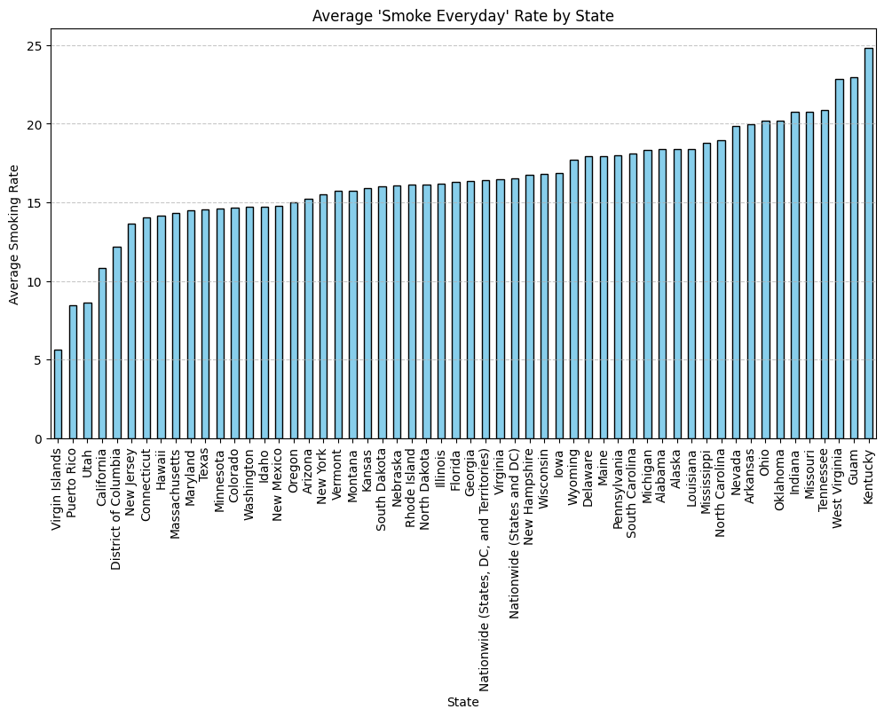

```python
# Group by State and calculate the mean of 'Smoke everyday'
state_avg_smoking = tobacco.groupby('State')['Smoke everyday'].mean().sort_values()

# Plot bar chart
plt.figure(figsize=(12, 6))
state_avg_smoking.plot(kind='bar', color='skyblue', edgecolor='black')

# Customize plot
plt.xlabel("State")
plt.ylabel("Average Smoking Rate")
plt.title("Average 'Smoke Everyday' Rate by State")
plt.xticks(rotation=90)  # Rotate x-axis labels for readability
plt.grid(axis='y', linestyle='--', alpha=0.7)

# Show plot
plt.show()
```

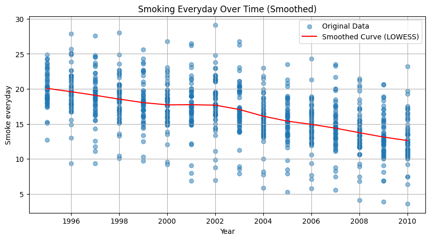

```python
# Sort by Year
tobacco = tobacco.sort_values(by='Year')

# Apply LOWESS smoothing
lowess = sm.nonparametric.lowess(tobacco['Smoke everyday'], tobacco['Year'], frac=0.2)  # Adjust frac for smoothness

# Plot original data
plt.figure(figsize=(10, 5))
plt.scatter(tobacco['Year'], tobacco['Smoke everyday'], label='Original Data', alpha=0.5)
plt.plot(lowess[:, 0], lowess[:, 1], color='red', label='Smoothed Curve (LOWESS)')
plt.xlabel('Year')
plt.ylabel('Smoke everyday')
plt.title('Smoking Everyday Over Time (Smoothed)')
plt.legend()
plt.grid(True)
plt.show()
```

# Dataset 2: Prevalence of Disability Status and Types 2016-2022

## Cleaning Dataset

Next we load and examine the DHDS disability dataset.

```python
# Import and name dhds dataset
dhds = pd.read_csv('../data/DHDS_-_Prevalence_of_Disability_Status_and_Types_20250313.csv')
pd.set_option('display.max_columns', None)  # Shows all columns
dhds.head()
```

|  | Year | LocationAbbr | LocationDesc | DataSource | Category | Indicator | Response | Data_Value_Unit | Data_Value_Type | Data_Value | Data_Value_Alt | Data_Value_Footnote_Symbol | Data_Value_Footnote | Low_Confidence_Limit | High_Confidence_Limit | Number | WeightedNumber | StratificationCategory1 | Stratification1 | StratificationCategory2 | Stratification2 | CategoryID | IndicatorID | LocationID | ResponseID | DataValueTypeID | StratificationCategoryID1 | StratificationID1 | StratificationCategoryID2 | … |
| --- | --- | --- | --- | --- | --- | --- | --- | --- | --- | --- | --- | --- | --- | --- | --- | --- | --- | --- | --- | --- | --- | --- | --- | --- | --- | --- | --- | --- | --- | --- |
| 0 | 2022 | NJ | New Jersey | BRFSS | Disability Estimates | Disability status and types among adults 18 ye... | Cognitive Disability | % | Age-adjusted Prevalence | 10.4 | 10.4 | NaN | NaN | 9.3 | 11.6 | 626.0 | 657448.0 | Overall | Overall | NaN | NaN | DISEST | STATTYPE | 34 | Q6COG | AGEADJPREV | CAT1 | BO1 | NaN | … |
| 1 | 2022 | WI | Wisconsin | BRFSS | Disability Estimates | Disability status and types among adults 18 ye... | Cognitive Disability | % | Age-adjusted Prevalence | 13.9 | 13.9 | NaN | NaN | 12.9 | 15.0 | 1201.0 | 573816.0 | Overall | Overall | NaN | NaN | DISEST | STATTYPE | 55 | Q6COG | AGEADJPREV | CAT1 | BO1 | NaN | … |
| 2 | 2022 | OH | Ohio | BRFSS | Disability Estimates | Disability status and types among adults 18 ye... | Self-care Disability | % | Age-adjusted Prevalence | 3.8 | 3.8 | NaN | NaN | 3.3 | 4.4 | 684.0 | 347270.0 | Overall | Overall | NaN | NaN | DISEST | STATTYPE | 39 | Q6SEL | AGEADJPREV | CAT1 | BO1 | NaN | … |
| 3 | 2022 | AR | Arkansas | BRFSS | Disability Estimates | Disability status and types among adults 18 ye... | Self-care Disability | % | Age-adjusted Prevalence | 5.4 | 5.4 | NaN | NaN | 4.6 | 6.3 | 310.0 | 123532.0 | Overall | Overall | NaN | NaN | DISEST | STATTYPE | 5 | Q6SEL | AGEADJPREV | CAT1 | BO1 | NaN | … |
| 4 | 2022 | DE | Delaware | BRFSS | Disability Estimates | Disability status and types among adults 18 ye... | No Disability | % | Age-adjusted Prevalence | 74.9 | 74.9 | NaN | NaN | 72.8 | 76.8 | 2664.0 | 553731.0 | Overall | Overall | NaN | NaN | DISEST | STATTYPE | 10 | Q6DIS2 | AGEADJPREV | CAT1 | BO1 | NaN | … |

```python
print(f"Dataset shape: {dhds.shape}")
```

```
Dataset shape: (3592, 30)
```

This dataset seems much messier than the tobacco usage data. Let's focus in one the columns we actually need for further analysis, and try to understand the information in the (quite vague) column headers. Beginning by figuring out if these values are unique or can be dropped.

```python
# Iterate through the columns and print unique values for each categorical column
for col in dhds.columns:
    if dhds[col].dtype == 'category' or dhds[col].dtype == 'object':  # Check object type
        print(f"Unique values in column '{col}': {dhds[col].unique()}")
        print("-" * 40) #separator for better readability

# Calculate and print the number of unique values for each categorical column
for col in dhds.columns:
  if dhds[col].dtype == 'category' or dhds[col].dtype == 'object':
    print(f"Column '{col}' has {dhds[col].nunique()} unique values.")
```

```
Unique values in column 'LocationAbbr': ['NJ' 'WI' 'OH' 'AR' 'DE' 'AK' 'GU' 'VI' 'IA' 'HHS8' 'TX' 'OK' 'PA' 'UT'
 'DC' 'MA' 'HHS2' 'HHS6' 'KS' 'US' 'WV' 'MD' 'ID' 'IL' 'HHS1' 'HI' 'MI'
 'LA' 'WA' 'KY' 'VT' 'NV' 'GA' 'FL' 'MT' 'MN' 'TN' 'WY' 'SC' 'CO' 'ME'
 'NY' 'NC' 'NM' 'IN' 'CT' 'PR' 'HHS3' 'HHS7' 'HHS4' 'OR' 'NE' 'SD' 'AL'
 'VA' 'CA' 'HHS10' 'ND' 'MS' 'MO' 'HHS5' 'AZ' 'HHS9' 'NH' 'RI']
----------------------------------------
Unique values in column 'LocationDesc': ['New Jersey' 'Wisconsin' 'Ohio' 'Arkansas' 'Delaware' 'Alaska' 'Guam'
 'U.S. Virgin Islands' 'Iowa' 'HHS Region 8' 'Texas' 'Oklahoma'
 'Pennsylvania' 'Utah' 'District of Columbia' 'Massachusetts'
 'HHS Region 2' 'HHS Region 6' 'Kansas' 'United States, DC & Territories'
 'West Virginia' 'Maryland' 'Idaho' 'Illinois' 'HHS Region 1' 'Hawaii'
 'Michigan' 'Louisiana' 'Washington' 'Kentucky' 'Vermont' 'Nevada'
 'Georgia' 'Florida' 'Montana' 'Minnesota' 'Tennessee' 'Wyoming'
 'South Carolina' 'Colorado' 'Maine' 'New York' 'North Carolina'
 'New Mexico' 'Indiana' 'Connecticut' 'Puerto Rico' 'HHS Region 3'
 'HHS Region 7' 'HHS Region 4' 'Oregon' 'Nebraska' 'South Dakota'
 'Alabama' 'Virginia' 'California' 'HHS Region 10' 'North Dakota'
 'Mississippi' 'Missouri' 'HHS Region 5' 'Arizona' 'HHS Region 9'
 'New Hampshire' 'Rhode Island']
----------------------------------------
Unique values in column 'DataSource': ['BRFSS']
----------------------------------------
Unique values in column 'Category': ['Disability Estimates']
----------------------------------------
Unique values in column 'Indicator': ['Disability status and types among adults 18 years of age or older']
----------------------------------------
Unique values in column 'Response': ['Cognitive Disability' 'Self-care Disability' 'No Disability'
 'Vision Disability' 'Mobility Disability' 'Any Disability'
 'Hearing Disability' 'Independent Living Disability']
----------------------------------------
Unique values in column 'Data_Value_Unit': ['%']
----------------------------------------
Unique values in column 'Data_Value_Type': ['Age-adjusted Prevalence']
----------------------------------------
Unique values in column 'Data_Value_Footnote_Symbol': [nan '*']
----------------------------------------
Unique values in column 'Data_Value_Footnote': [nan 'Data suppressed']
----------------------------------------
Unique values in column 'StratificationCategory1': ['Overall']
----------------------------------------
```

[output cut: 17 more lines]

```
Column 'Category' has 1 unique values.
Column 'Indicator' has 1 unique values.
Column 'Response' has 8 unique values.
Column 'Data_Value_Unit' has 1 unique values.
Column 'Data_Value_Type' has 1 unique values.
Column 'Data_Value_Footnote_Symbol' has 1 unique values.
Column 'Data_Value_Footnote' has 1 unique values.
Column 'StratificationCategory1' has 1 unique values.
Column 'Stratification1' has 1 unique values.
Column 'CategoryID' has 1 unique values.
Column 'IndicatorID' has 1 unique values.
Column 'ResponseID' has 8 unique values.
Column 'DataValueTypeID' has 1 unique values.
Column 'StratificationCategoryID1' has 1 unique values.
Column 'StratificationID1' has 1 unique values.
```

All the columns with only one unique value can be dropped. Let's see how this dataset appears with only columns with relevant information. Data val and data val alt are also copies, and have the same information.

```python
# Print original shape
print(f"Original shape: {dhds.shape}")

# Drop unnecessary columns
columns_to_drop = [
    "DataSource",               # Always 'BRFSS'
    "Category",                 # Always 'Disability Estimates'
    "Indicator",                # Always 'Disability status and types among adults 18 years of age or older'
    "Data_Value_Unit",          # Always '%'
    "Data_Value_Type",          # Always 'Age-adjusted Prevalence'
    "StratificationCategory1",  # Always 'Overall'
    "Stratification1",          # Always 'Overall'
    "CategoryID",               # Always 'DISEST'
    "IndicatorID",              # Always 'STATTYPE'
    "LocationID",               # Already have state
    "DataValueTypeID",          # Always 'AGEADJPREV'
    "StratificationCategoryID1",# Always 'CAT1'
    "StratificationID1",        # Always 'BO1'

    # Redundant columns
    "Data_Value_Alt",           # Same as Data_Value

    # ID columns with no analytical value
    "ResponseID",               # Encodes the same info as 'Response'

    # Sparse columns
    "Data_Value_Footnote_Symbol", # Mostly NaN with some '*'
    "Data_Value_Footnote",        # Mostly NaN with some 'Data suppressed'
    "StratificationCategory2",    # Not in unique values list, likely sparse
    "Stratification2",            # Not in unique values list, likely sparse
    "StratificationCategoryID2",  # Not in unique values list, likely sparse
    "StratificationID2"           # Not in unique values list, likely sparse
]

# Check if all columns exist
columns_to_drop = [col for col in columns_to_drop if col in dhds.columns]
dhds_clean = dhds.drop(columns=columns_to_drop)

# Keep LocationDesc for reference but create a state-name mapping dictionary
state_names = dict(zip(dhds['LocationAbbr'], dhds['LocationDesc']))

# Then drop LocationDesc
if 'LocationDesc' in dhds_clean.columns:
    dhds_clean = dhds_clean.drop(columns=['LocationDesc'])

# Convert data types
dhds_clean['Year'] = dhds_clean['Year'].astype(int)
dhds_clean['Data_Value'] = dhds_clean['Data_Value'].astype(float)
dhds_clean['Low_Confidence_Limit'] = dhds_clean['Low_Confidence_Limit'].astype(float)
dhds_clean['High_Confidence_Limit'] = dhds_clean['High_Confidence_Limit'].astype(float)
dhds_clean['Number'] = dhds_clean['Number'].astype(float)
dhds_clean['WeightedNumber'] = dhds_clean['WeightedNumber'].astype(float)

# Rename columns for clarity
column_rename = {
    'LocationAbbr': 'state',
    'Response': 'disability_type',
    'Data_Value': 'prevalence_pct',
    'Low_Confidence_Limit': 'ci_lower',
    'High_Confidence_Limit': 'ci_upper',
    'Number': 'sample_size',
    'WeightedNumber': 'population_estimate'
}

dhds_clean = dhds_clean.rename(columns=column_rename)

# Create a new column for simplified disability category
dhds_clean['disability_category'] = dhds_clean['disability_type'].str.replace(' Disability', '')

# Handle special case for 'No Disability'
dhds_clean['disability_category'] = dhds_clean['disability_category'].replace('No', 'None')

# Check for any remaining missing values
missing_values = dhds_clean.isnull().sum()
print(f"Columns with missing values:\n{missing_values[missing_values > 0]}")

# Calculate confidence interval width (uncertainty measure)
dhds_clean['ci_width'] = dhds_clean['ci_upper'] - dhds_clean['ci_lower']

# Add a flag for data quality (wider CI = less reliable)
dhds_clean['low_reliability'] = dhds_clean['ci_width'] > 5  # Flag CIs wider than 5 percentage points

# Display cleaned dataset info
print(f"Cleaned shape: {dhds_clean.shape}")
print(f"Columns in cleaned dataset: {list(dhds_clean.columns)}")

# Display first few rows of cleaned dataset
print("\nSample of cleaned dataset:")
print(dhds_clean.head())

# Save cleaned dataset
dhds_clean.to_csv('dhds_clean.csv', index=False)
print("\nCleaned dataset saved to 'dhds_clean.csv'")

# Basic summary statistics
print("\nSummary statistics for prevalence percentages:")
print(dhds_clean.groupby('disability_category')['prevalence_pct'].describe())
```

```
Original shape: (3592, 30)
Columns with missing values:
prevalence_pct         5
ci_lower               5
ci_upper               5
sample_size            5
population_estimate    5
dtype: int64
Cleaned shape: (3592, 11)
Columns in cleaned dataset: ['Year', 'state', 'disability_type', 'prevalence_pct', 'ci_lower', 'ci_upper', 'sample_size', 'population_estimate', 'disability_category', 'ci_width', 'low_reliability']

Sample of cleaned dataset:
   Year state       disability_type  prevalence_pct  ci_lower  ci_upper  \
0  2022    NJ  Cognitive Disability            10.4       9.3      11.6
1  2022    WI  Cognitive Disability            13.9      12.9      15.0
2  2022    OH  Self-care Disability             3.8       3.3       4.4
3  2022    AR  Self-care Disability             5.4       4.6       6.3
4  2022    DE         No Disability            74.9      72.8      76.8

   sample_size  population_estimate disability_category  ci_width  \
0        626.0             657448.0           Cognitive       2.3
1       1201.0             573816.0           Cognitive       2.1
2        684.0             347270.0           Self-care       1.1
3        310.0             123532.0           Self-care       1.7
4       2664.0             553731.0                None       4.0

   low_reliability
0            False
1            False
2            False
3            False
4            False

Cleaned dataset saved to 'dhds_clean.csv'

Summary statistics for prevalence percentages:
                     count       mean       std   min   25%   50%   75%   max
disability_category
Any                  449.0  26.502895  4.391669  18.7  23.3  25.7  28.7  42.2
Cognitive            449.0  12.033630  2.482574   6.9  10.1  11.6  13.6  19.9
Hearing              449.0   6.199332  1.427027   3.1   5.3   6.0   6.8  12.4
Independent Living   448.0   6.996205  1.585253   3.7   5.9   6.8   7.8  12.8
Mobility             449.0  12.230512  2.812001   7.2  10.2  11.7  13.6  21.8
None                 449.0  73.497105  4.391669  57.8  71.3  74.3  76.7  81.3
Self-care            445.0   3.471461  0.968452   1.8   2.8   3.3   3.9   7.4
Vision               449.0   4.915813  2.034928   2.4   3.7   4.5   5.7  19.1
```

Let's visualize this cleaned dataset with a boxplot.

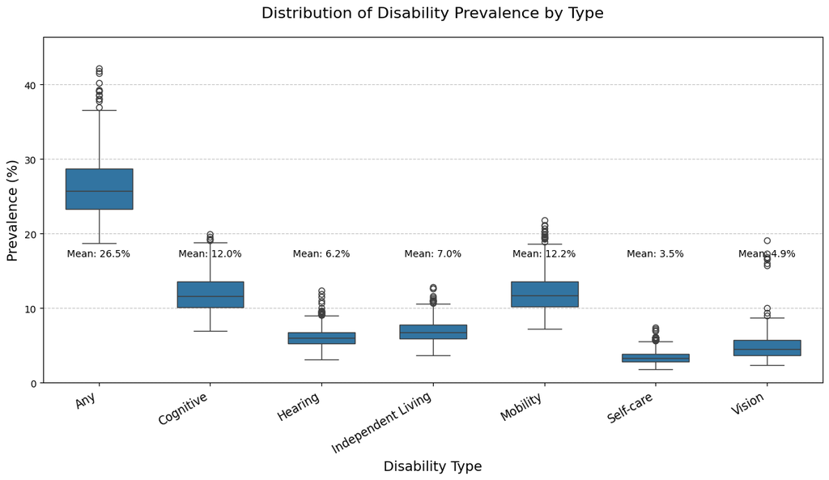

```python
plt.figure(figsize=(12, 7))

# Filter out the 'None' category
disability_data = dhds_clean[dhds_clean['disability_category'] != 'None']

# Create a custom order with 'Any' first
category_order = ['Any']
other_categories = sorted([cat for cat in disability_data['disability_category'].unique() if cat != 'Any'])
category_order.extend(other_categories)

# Create the boxplot
ax = sns.boxplot(
    x='disability_category',
    y='prevalence_pct',
    data=disability_data,
    order=category_order,
    width=0.6,
    linewidth=1,
    legend=True
)

# Add a title and labels
plt.title('Distribution of Disability Prevalence by Type', fontsize=16, pad=20)
plt.ylabel('Prevalence (%)', fontsize=14)
plt.xlabel('Disability Type', fontsize=14)
plt.xticks(rotation=30, ha='right', fontsize=12)

# Add grid lines
plt.grid(axis='y', linestyle='--', alpha=0.7)

# Customize y-axis limits
plt.ylim(0, max(disability_data['prevalence_pct']) * 1.1)

# Add mean markers
for i, disability in enumerate(category_order):
    mean_val = disability_data[disability_data['disability_category'] == disability]['prevalence_pct'].mean()
    y_pos = 18
    ax.text(i, y_pos, f'Mean: {mean_val:.1f}%', ha='center', va='top', fontsize=10)

plt.tight_layout()
```

We now have gone from 30+ columns to 11 essential columns, while preserving important information about confidence intervals. Now we can continue to explore this dataset.

## Ranking Based on Cognitive Disability Percentage

Since different years are stored in different rows, we will sue only the 2022 data (most recent in the dataset). We can rank all 50 states based on percentage of cognitive disability.

```python
# Filter for cognitive disability type from the cleaned dataset
cognitive = dhds_clean[dhds_clean['disability_category'] == 'Cognitive']

most_recent_year = 2022

# Filter for just 2022
recent_cognitive = cognitive[cognitive['Year'] == most_recent_year]

# Sort states by prevalence rate (descending)
cognitive_by_state = recent_cognitive.sort_values('prevalence_pct', ascending=False)

# Assuming state codes for actual states are 2 letters
state_cognitive = cognitive_by_state[cognitive_by_state['state'].str.len() == 2]

# Show top 5 states with highest rates
print("\nStates with highest cognitive disability rates:")
result_table = state_cognitive[['state', 'prevalence_pct', 'ci_lower', 'ci_upper', 'sample_size']].head(5)

if 'state_names' in locals():
  result_table['State Name'] = result_table['state'].map(state_names)

# Rename columns
result_table = result_table.rename(columns={
    'state': 'State',
    'prevalence_pct': 'Prevalence (%)',
    'ci_lower': 'Lower CI',
    'ci_upper': 'Upper CI',
    'sample_size': 'Sample Size'
})

# Print table
print(result_table)

# Calculate the national average for 2022
us_data = cognitive[(cognitive['state'] == 'US') & (cognitive['Year'] == most_recent_year)]
if not us_data.empty:
    national_avg = us_data['prevalence_pct'].values[0]
    print(f"\nNational average cognitive disability prevalence: {national_avg:.1f}%")
```

```
States with highest cognitive disability rates:
    State  Prevalence (%)  Lower CI  Upper CI  Sample Size     State Name
255    AR            19.9      18.2      21.7        786.0       Arkansas
383    WV            19.3      17.7      20.9        844.0  West Virginia
30     LA            19.3      17.8      21.0        855.0      Louisiana
279    PR            18.6      17.1      20.2        999.0    Puerto Rico
79     OK            18.1      16.8      19.5        925.0       Oklahoma

National average cognitive disability prevalence: 13.9%
```

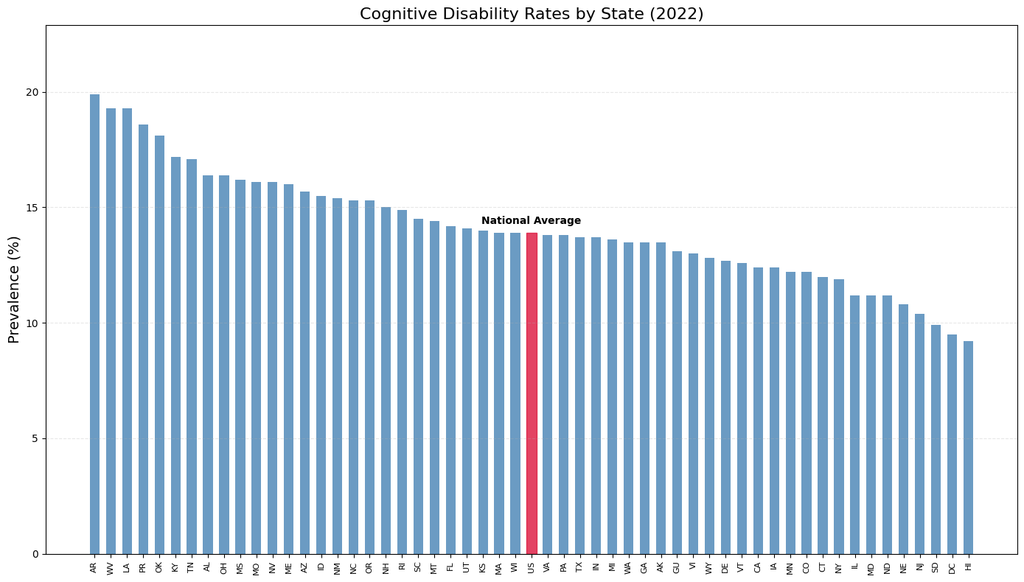

```python
# Get all state data
state_cognitive = recent_cognitive[recent_cognitive['state'].str.len() == 2]

# Sort all states by prevalence rate
all_states = state_cognitive.sort_values('prevalence_pct', ascending=False)

plt.figure(figsize=(14, 8))

# Create the bar chart for all states
bars = plt.bar(all_states['state'], all_states['prevalence_pct'],
        color='steelblue', alpha=0.8, width=0.6)

# Find and highlight the US bar
for i, state in enumerate(all_states['state']):
    if state == 'US':
        # Change color of US bar
        bars[i].set_color('crimson')

        # Add a label
        height = bars[i].get_height()
        plt.text(bars[i].get_x() + bars[i].get_width()/2., height + 0.3,
                "National Average",
                ha='center', va='bottom', fontsize=10, fontweight='bold')
        break

# Customize the chart
plt.title(f'Cognitive Disability Rates by State ({most_recent_year})', fontsize=16)
plt.ylabel('Prevalence (%)', fontsize=14)
plt.grid(axis='y', linestyle='--', alpha=0.3)
plt.ylim(0, max(all_states['prevalence_pct']) * 1.15)  # Room for labels
plt.xticks(rotation=90, ha='center', fontsize=8)  # Vertical labels for readability with many states

plt.tight_layout()
plt.show()
```

We now have some sense of the distribution of cognitive disability rates by state. Let's look at how some of these rates have changed over time.

## Disability Trends Over Time

The dataset only covers the years 2016-2022, but let's see if there are any trends over this period.

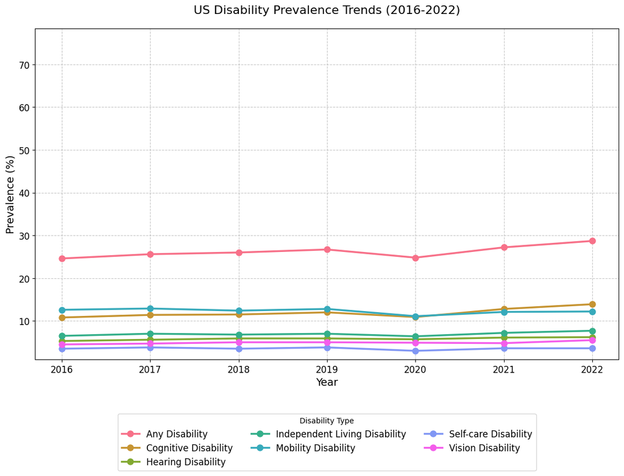

```python
# Filter for US national data only and years 2016-2022
us_data = dhds_clean[
    (dhds_clean['state'] == 'US') &
    (dhds_clean['Year'] >= 2016) &
    (dhds_clean['Year'] <= 2022)
]

# Get list of disability types (excluding 'No Disability')
disability_types = sorted([
    d_type for d_type in us_data['disability_type'].unique()
    if d_type != 'No Disability'
])

plt.figure(figsize=(14, 8))

# Set colors
colors = sns.color_palette("husl", len(disability_types))

# Plot each disability type
for i, disability in enumerate(disability_types):
    type_data = us_data[us_data['disability_type'] == disability]

    # Sort by year
    type_data = type_data.sort_values('Year')

    # Plot the line
    plt.plot(
        type_data['Year'],
        type_data['prevalence_pct'],
        marker='o',
        markersize=8,
        linewidth=2.5,
        color=colors[i],
        label=disability
    )

# Customize the chart appearance
plt.title('US Disability Prevalence Trends (2016-2022)', fontsize=16, pad=20)
plt.xlabel('Year', fontsize=14)
plt.ylabel('Prevalence (%)', fontsize=14)
plt.grid(True, linestyle='--', alpha=0.7)
plt.xticks(range(2016, 2023), fontsize=12)
plt.yticks(fontsize=12)

# Set y-axis range with some padding
y_min = max(0, us_data['prevalence_pct'].min() - 2)
y_max = us_data['prevalence_pct'].max() + 3
plt.ylim(y_min, y_max)

# Add a legend with a nice layout
plt.legend(
    title='Disability Type',
    loc='upper center',
    bbox_to_anchor=(0.5, -0.15),
    ncol=3,
    frameon=True,
    fontsize=12
)
```

As expected, rates are relatively constant over this period. Cognitive disability rates have increased to become the most common subtype over mobility disability. The national prevalence has also increased over this time.

## Geographic Analysis

We will now create some geographic visualizations of disability data, and compare with tobacco usage data. We will use the year 2010, since it is the most recent from the tobacco dataset. However, the DHDS data spans from 2016-2022. Hence we can only compare 2016 data.

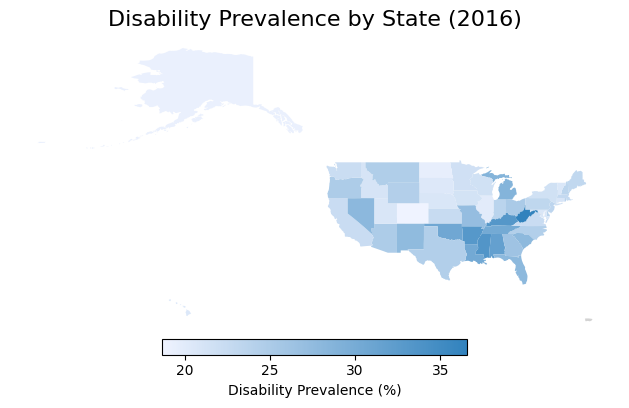

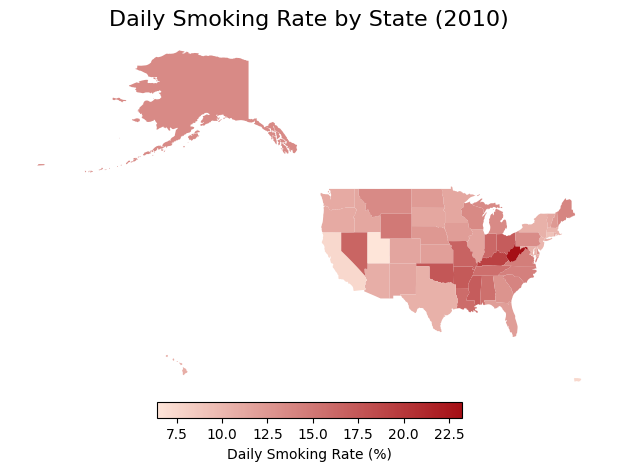

```python
# Download US states geojson for mapping
usa = gpd.read_file('https://raw.githubusercontent.com/PublicaMundi/MappingAPI/master/data/geojson/us-states.json')

# Get the most recent year data for both datasets
latest_disability_year = 2016
latest_tobacco_year = 2010

# 1. Disability Geographic Map

# Filter for 'Any Disability' in most recent year
disability_data = dhds_clean[
    (dhds_clean['disability_type'] == 'Any Disability') &
    (dhds_clean['Year'] == latest_disability_year)
]

# Create df with state names and disability rates
disability_map_data = pd.DataFrame({
    'state_name': disability_data['state'].map(state_names),
    'disability_rate': disability_data['prevalence_pct']
})

# Remove territories
disability_map_data = disability_map_data[
    ~disability_map_data['state_name'].isin(['United States', 'District of Columbia', 'Puerto Rico', 'Guam', 'Virgin Islands'])
]

# Merge with geographic data
disability_merged = usa.merge(
    disability_map_data,
    left_on='name',
    right_on='state_name',
    how='left'
)

# Create the disability choropleth map
plt.figure(figsize=(40, 30))

# Custom color map for disability data
disability_cmap = LinearSegmentedColormap.from_list(
    'disability_cmap', ['#eff3ff', '#3182bd'], N=256
)

# Plot the map
disability_merged.plot(
    column='disability_rate',
    cmap=disability_cmap,
    legend=True,
    missing_kwds={'color': 'lightgray'},
    legend_kwds={
        'label': 'Disability Prevalence (%)',
        'orientation': 'horizontal',
        'shrink': 0.5,
        'pad': 0.01
    }
)

plt.title(f'Disability Prevalence by State ({latest_disability_year})', fontsize=16)
plt.axis('off')
plt.tight_layout()
plt.savefig('disability_map.png', dpi=300, bbox_inches='tight')
plt.show()

# 2. Tobacco Geographic Map

tobacco_recent = tobacco[tobacco['Year'] == latest_tobacco_year]

# Group by state and calculate mean rate
tobacco_by_state = tobacco_recent.groupby('State')['Smoke everyday'].mean().reset_index()

# Create df
tobacco_map_data = pd.DataFrame({
    'state_name': tobacco_by_state['State'],
    'smoking_rate': tobacco_by_state['Smoke everyday']
})

# Merge with geographic data
tobacco_merged = usa.merge(
    tobacco_map_data,
    left_on='name',
    right_on='state_name',
    how='left'
)

plt.figure(figsize=(40, 30))

# Color map
tobacco_cmap = LinearSegmentedColormap.from_list(
    'tobacco_cmap', ['#fee5d9', '#a50f15'], N=256
)

# Plot
tobacco_merged.plot(
    column='smoking_rate',
    cmap=tobacco_cmap,
    legend=True,
    missing_kwds={'color': 'lightgray'},
    legend_kwds={
        'label': 'Daily Smoking Rate (%)',
        'orientation': 'horizontal',
        'shrink': 0.5,
        'pad': 0.01
    }
)

plt.title(f'Daily Smoking Rate by State ({latest_tobacco_year})', fontsize=16)
plt.axis('off')
plt.tight_layout()
plt.savefig('smoking_map.png', dpi=300, bbox_inches='tight')
plt.show()
```

It seems like there may be some relationship between daily smoking rate and any disability status. Let's explore this relationship further.

## Relationships Between Tobacco Usage and Disability Status

In the following section we extract the most recent years for both the disability and tobacco datasets, map the state codes for both, and perform an inner join of the datasets. We then calculate a Pearson coefficient for the two variables.

```
Correlation Statistics:
Pearson correlation: r = 0.763, p-value = 0.0000
R² (coefficient of determination): 0.583
```

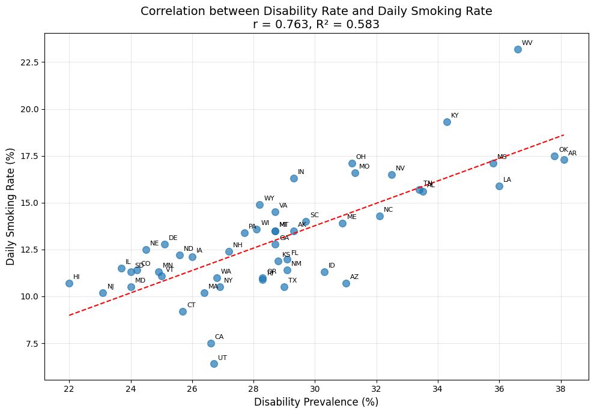

```python
# Using most recent years
latest_disability_year = 2022
latest_tobacco_year = 2010

# Prepare disability data
disability_data = dhds_clean[
    (dhds_clean['disability_type'] == 'Any Disability') &
    (dhds_clean['Year'] == latest_disability_year)
]

# Keep only state-level data
disability_states = disability_data[
    (disability_data['state'].str.len() == 2) &
    (~disability_data['state'].isin(['US', 'DC', 'PR', 'GU', 'VI']))
]

# Create a clean df
disability_df = pd.DataFrame({
    'state': disability_states['state'],
    'disability_rate': disability_states['prevalence_pct']
})

# Prepare tobacco data
tobacco_recent = tobacco[tobacco['Year'] == latest_tobacco_year]

# Group by state and calculate mean
tobacco_by_state = tobacco_recent.groupby('State')['Smoke everyday'].mean().reset_index()

# State mapping dictionary
state_name_to_code = {
    'Alabama': 'AL', 'Alaska': 'AK', 'Arizona': 'AZ', 'Arkansas': 'AR',
    'California': 'CA', 'Colorado': 'CO', 'Connecticut': 'CT', 'Delaware': 'DE',
    'Florida': 'FL', 'Georgia': 'GA', 'Hawaii': 'HI', 'Idaho': 'ID',
    'Illinois': 'IL', 'Indiana': 'IN', 'Iowa': 'IA', 'Kansas': 'KS',
    'Kentucky': 'KY', 'Louisiana': 'LA', 'Maine': 'ME', 'Maryland': 'MD',
    'Massachusetts': 'MA', 'Michigan': 'MI', 'Minnesota': 'MN', 'Mississippi': 'MS',
    'Missouri': 'MO', 'Montana': 'MT', 'Nebraska': 'NE', 'Nevada': 'NV',
    'New Hampshire': 'NH', 'New Jersey': 'NJ', 'New Mexico': 'NM', 'New York': 'NY',
    'North Carolina': 'NC', 'North Dakota': 'ND', 'Ohio': 'OH', 'Oklahoma': 'OK',
    'Oregon': 'OR', 'Pennsylvania': 'PA', 'Rhode Island': 'RI', 'South Carolina': 'SC',
    'South Dakota': 'SD', 'Tennessee': 'TN', 'Texas': 'TX', 'Utah': 'UT',
    'Vermont': 'VT', 'Virginia': 'VA', 'Washington': 'WA', 'West Virginia': 'WV',
    'Wisconsin': 'WI', 'Wyoming': 'WY'
}

# Add state codes to tobacco dataset
tobacco_by_state['state_code'] = tobacco_by_state['State'].map(state_name_to_code)

# Merge datasets on state code
merged_df = pd.merge(
    disability_df,
    tobacco_by_state,
    left_on='state',
    right_on='state_code',
    how='inner'
)

# Calculate Pearson correlation
pearson_corr, p_value = stats.pearsonr(merged_df['disability_rate'], merged_df['Smoke everyday'])

print("\nCorrelation Statistics:")
print(f"Pearson correlation: r = {pearson_corr:.3f}, p-value = {p_value:.4f}")
print(f"R² (coefficient of determination): {pearson_corr**2:.3f}")


plt.figure(figsize=(10, 7))

# Create scatter plot
plt.scatter(
    merged_df['disability_rate'],
    merged_df['Smoke everyday'],
    alpha=0.7,
    s=70
)

# Add regression line
slope, intercept = np.polyfit(merged_df['disability_rate'], merged_df['Smoke everyday'], 1)
x_line = np.linspace(merged_df['disability_rate'].min(), merged_df['disability_rate'].max(), 100)
y_line = slope * x_line + intercept
plt.plot(x_line, y_line, color='red', linestyle='--')

# Add labels for all states
for idx, row in merged_df.iterrows():
    plt.annotate(
        row['state'],
        (row['disability_rate'], row['Smoke everyday']),
        xytext=(5, 5),
        textcoords='offset points',
        fontsize=8
    )

# Add title and labels
plt.title(f'Correlation between Disability Rate and Daily Smoking Rate\nr = {pearson_corr:.3f}, R² = {pearson_corr**2:.3f}', fontsize=14)
plt.xlabel('Disability Prevalence (%)', fontsize=12)
plt.ylabel('Daily Smoking Rate (%)', fontsize=12)
plt.grid(True, alpha=0.3)

plt.tight_layout()
plt.savefig('disability_smoking_correlation.png', dpi=300)
plt.show()
```

A reasonably strong Pearson coefficient was found, suggesting a strong correlation between disability prevalence (any type) and daily smoking behaviors.

# Building Models

## Logistic Regression for Tobacco Dataset

Now it's time to build our model! We want to examine the relationship between year and state and smoker characteristics. We have a few different options when we are trying to predict the smoker characteristics based on the year/state inputs.

We initially tried to use linear and polynomial regression, but we ran into a major problem: these models can predict values outside of our range (0-100%)! Obviously, we cannot have (for example) -4.7% of people who have never smoked, so we had to change strategies.

We decided to use a logistic regression on logit-transformed data with polynomial year terms for the following reasons:

1. Linear regression models predict values anywhere from −∞ to +∞, which is problematic for percentages. By applying the logit transformation to percentages (rescaling from [0, 100] → [0, 1] → (−∞, +∞)), we can:
- Fit a linear model on the log-odds scale (unbounded)
- Then transform predictions back using the inverse logit, ensuring values stay in the [0, 1] range
- Multiply by 100 to return to percentage scale
2. We can capture nonlinear trends over time. The problem is that smoking trends are rarely perfectly linear, so adding year as a polynomial term adds for more realistic curvature.
3. We can account for state-to-state differences. Clearly, different states have different cultural norms, laws, and demographics, which can vastly affect the smoking rates. For example, Kentucky has almost 3x the average smoking rate of Utah (as seen in our EDA), which is likely due to the large Mormon population in Utah, which drives their rates down.

We first need to define our logit and inverse logit functions

```python
# --- Helper functions for logit and inverse logit ---
def logit(p):
    p = np.clip(p, 1e-5, 1 - 1e-5)  # prevent log(0)
    return np.log(p / (1 - p))

def inv_logit(x):
    return 1 / (1 + np.exp(-x))
```

Next, we need to clean our data to ensure we can model on it, which includes removing NA values, converting our percentages to proportions, adding polynomial features, and encoding the state variable.

```python
# Remove any NA values
tobacco_clean = tobacco.dropna(subset=[
    'Year', 'State',
    'Smoke everyday', 'Smoke some days',
    'Former smoker', 'Never smoked'
])

# Convert target % columns to proportions
target_columns = ['Smoke everyday', 'Smoke some days', 'Former smoker', 'Never smoked']
for col in target_columns:
    tobacco_clean[col] = tobacco_clean[col] / 100

# Add polynomial features
tobacco_clean['Year2'] = tobacco_clean['Year'] ** 2

# OneHot encode 'State'
encoder = OneHotEncoder(handle_unknown='ignore', sparse_output=False)
state_encoded = encoder.fit_transform(tobacco_clean[['State']])
state_columns = encoder.get_feature_names_out(['State'])
```

```python
# Build model inputs
X_combined = pd.DataFrame(state_encoded, columns=state_columns)
X_combined['Year'] = tobacco_clean['Year'].values
X_combined['Year2'] = tobacco_clean['Year2'].values

# --- Create future prediction frame ---
future_years = list(range(2011, 2030))
# States to plot
plot_states = ['Alabama', 'Alaska', 'Arizona', 'Arkansas']
future_df = pd.DataFrame([(year, state) for state in plot_states for year in future_years],
                         columns=['Year', 'State'])
future_df['Year2'] = future_df['Year'] ** 2

future_encoded = encoder.transform(future_df[['State']])
future_X_combined = pd.DataFrame(future_encoded, columns=state_columns)
future_X_combined['Year'] = future_df['Year']
future_X_combined['Year2'] = future_df['Year2']
```

We then fit the model. We want to plot some of the predictions, but we don't want the plot to get too messy with over 50 different predictions, so we grab an arbitrary list of four to plot so we can get an idea of what the model is doing.

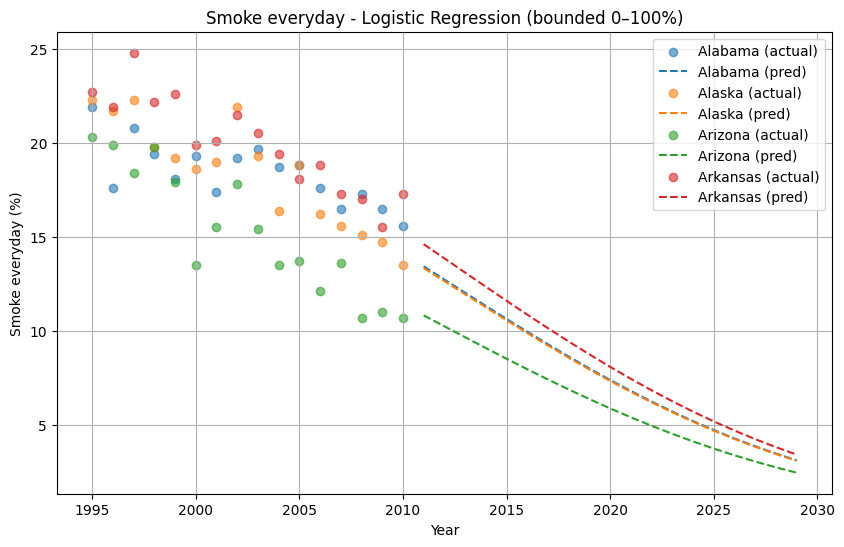

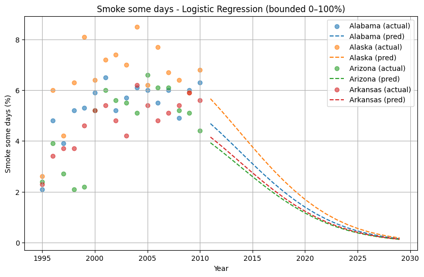

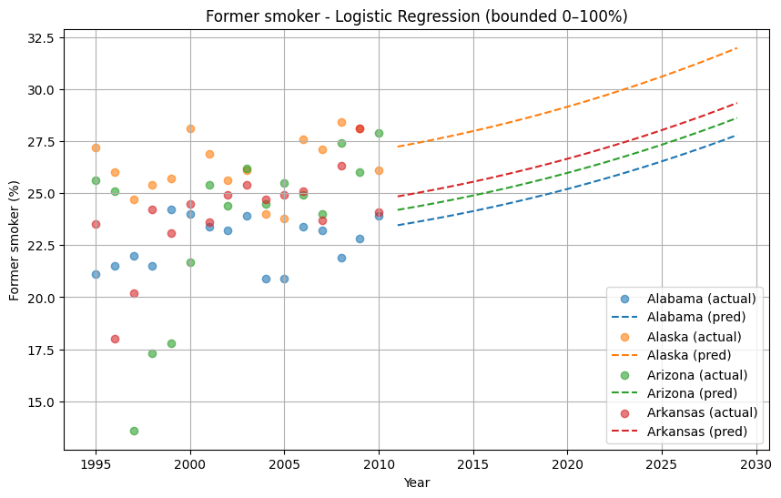

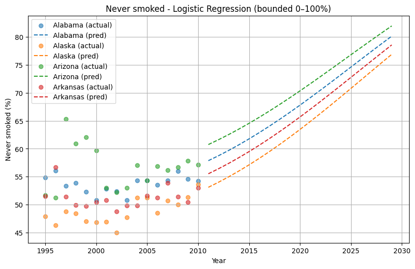

```python
# States to plot
plot_states = ['Alabama', 'Alaska', 'Arizona', 'Arkansas']

# --- Fit and predict ---
models = {}
future_predictions = future_df.copy()

for col in target_columns:
    # Apply logit transformation
    y_logit = logit(tobacco_clean[col].values)

    # Fit model on logit values
    model = LinearRegression()
    model.fit(X_combined, y_logit)
    models[col] = model

    # Predict and apply inverse logit
    y_pred_logit = model.predict(future_X_combined)
    y_pred = inv_logit(y_pred_logit) * 100  # convert back to %
    future_predictions[col] = y_pred

    # --- Plot ---
    plt.figure(figsize=(10, 6))
    for state in plot_states:
        # Historical
        df_hist = tobacco_clean[tobacco_clean['State'] == state]
        plt.scatter(df_hist['Year'], df_hist[col] * 100, label=f"{state} (actual)", alpha=0.6)

        # Future
        df_pred = future_predictions[future_predictions['State'] == state]
        plt.plot(df_pred['Year'], df_pred[col], label=f"{state} (pred)", linestyle='--')

    plt.title(f"{col} - Logistic Regression (bounded 0–100%)")
    plt.xlabel("Year")
    plt.ylabel(f"{col} (%)")
    plt.legend()
    plt.grid(True)
    plt.show()
```

We also want to test some specific cases to see what the model outputs, so we'll try Puerto Rico in 2025, Washington in 2020, and New York in 2015.

```python
# Define the custom test cases
test_cases = pd.DataFrame({
    'Year': [2025, 2020, 2015],
    'State': ['Puerto Rico', 'Washington', 'New York']
})
test_cases['Year2'] = test_cases['Year'] ** 2
test_encoded = encoder.transform(test_cases[['State']])
test_X_combined = pd.DataFrame(test_encoded, columns=state_columns)
test_X_combined['Year'] = test_cases['Year']
test_X_combined['Year2'] = test_cases['Year2']

# Predict and print
print("Custom Example Predictions:\n")
for col in target_columns:
    logit_pred = models[col].predict(test_X_combined)
    prob_pred = inv_logit(logit_pred) * 100
    print(f"{col}:")
    for i, row in test_cases.iterrows():
        print(f"  {row['State']} ({row['Year']}): {prob_pred[i]:.2f}%")
    print()
```

```
Custom Example Predictions:

Smoke everyday:
  Puerto Rico (2025): 2.01%
  Washington (2020): 5.68%
  New York (2015): 8.72%

Smoke some days:
  Puerto Rico (2025): 0.38%
  Washington (2020): 1.24%
  New York (2015): 2.98%

Former smoker:
  Puerto Rico (2025): 19.95%
  Washington (2020): 29.98%
  New York (2015): 26.52%

Never smoked:
  Puerto Rico (2025): 85.66%
  Washington (2020): 67.65%
  New York (2015): 62.58%
```

## Predicting Disability Status Based on Tobacco Usage

We now want to examine the relationship between tobacco usage and disability status in a single year. Since we're working with percentages (both disability prevalence and smoking rates are expressed as percentages), we need to be careful about our modeling approach.

We'll use a similar approach to the tobacco prediction model, applying a logistic transformation to ensure our predictions stay within the valid range of 0-100%.

We can reuse the same logit helper functions as in the previous section. First we will need to clean and prepare our datasets.

```python
# Get the most recent years from both datasets
latest_disability_year = dhds_clean['Year'].max()
latest_tobacco_year = tobacco['Year'].max()

# Prepare disability data (need 'Any Disability')
disability_data = dhds_clean[
    (dhds_clean['disability_type'] == 'Any Disability') &
    (dhds_clean['Year'] == latest_disability_year)
]

# Keep only state-level data
disability_states = disability_data[
    (disability_data['state'].str.len() == 2) &
    (~disability_data['state'].isin(['US', 'DC', 'PR', 'GU', 'VI']))
]

# Create df with states and disability rates
disability_df = pd.DataFrame({
    'state': disability_states['state'],
    'disability_rate': disability_states['prevalence_pct'] / 100  # Convert to proportion
})

# Prepare tobacco data (features)
tobacco_recent = tobacco[tobacco['Year'] == latest_tobacco_year]

# Create mean smoking metrics by state
tobacco_features = tobacco_recent.groupby('State')[
    ['Smoke everyday', 'Smoke some days', 'Former smoker', 'Never smoked']
].mean().reset_index()

# Convert percentages to proportions
for col in ['Smoke everyday', 'Smoke some days', 'Former smoker', 'Never smoked']:
    tobacco_features[col] = tobacco_features[col] / 100
```

Next we can merge datasets and our create feature list.

```python
# Add state codes to tobacco dataset
tobacco_features['state_code'] = tobacco_features['State'].map(state_name_to_code)

# Merge datasets on state code
merged_df = pd.merge(
    disability_df,
    tobacco_features,
    left_on='state',
    right_on='state_code',
    how='inner'
)

# Check the merged data
print(merged_df.head())
```

```
  state  disability_rate      State  Smoke everyday  Smoke some days  \
0    IA            0.260       Iowa           0.121            0.041
1    UT            0.267       Utah           0.064            0.027
2    ID            0.303      Idaho           0.113            0.044
3    NV            0.325     Nevada           0.165            0.049
4    TN            0.334  Tennessee           0.157            0.044

   Former smoker  Never smoked state_code
0          0.234         0.604         IA
1          0.143         0.766         UT
2          0.229         0.615         ID
3          0.258         0.528         NV
4          0.229         0.570         TN
```

We can now move to building and training our model.

```python
# Define features and target
X = merged_df[['Smoke everyday', 'Smoke some days', 'Former smoker', 'Never smoked']]
y = merged_df['disability_rate']

# Apply logit transformation to target
y_logit = logit(y)

# Create and train the model
model = LinearRegression()
model.fit(X, y_logit)

# Get model coefficients
coefficients = pd.DataFrame({
    'Feature': X.columns,
    'Coefficient': model.coef_
})

print("Model Coefficients:")
print(coefficients)

# Calculate fitted values and convert back to percentages
y_pred_logit = model.predict(X)
y_pred = inv_logit(y_pred_logit) * 100  # Convert back to percentages
merged_df['predicted_disability'] = y_pred

# Calculate metrics
y_actual = merged_df['disability_rate'] * 100  # Convert actual values to percentages
mse = mean_squared_error(y_actual, y_pred)
r2 = r2_score(y_actual, y_pred)

print(f"\nModel Performance:")
print(f"Mean Squared Error: {mse:.4f}")
print(f"R-squared: {r2:.4f}")
print(f"Root Mean Squared Error: {np.sqrt(mse):.4f} percentage points")
```

```
Model Coefficients:
           Feature  Coefficient
0   Smoke everyday    41.895094
1  Smoke some days    41.119169
2    Former smoker    36.428311
3     Never smoked    37.543490

Model Performance:
Mean Squared Error: 5.0297
R-squared: 0.6608
Root Mean Squared Error: 2.2427 percentage points
```

Finally, let's try visualizing the performance of our model.

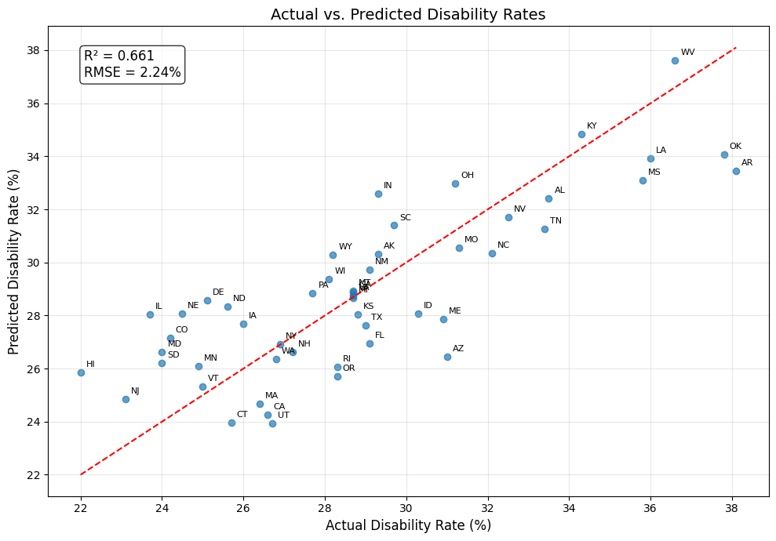

```python
# Create a scatter plot of actual vs. predicted values
plt.figure(figsize=(10, 7))
plt.scatter(merged_df['disability_rate'] * 100, y_pred, alpha=0.7)

# Add perfect prediction line
min_val = min(merged_df['disability_rate'].min() * 100, y_pred.min())
max_val = max(merged_df['disability_rate'].max() * 100, y_pred.max())
plt.plot([min_val, max_val], [min_val, max_val], 'r--')

# Add state labels
for idx, row in merged_df.iterrows():
    plt.annotate(
        row['state'],
        (row['disability_rate'] * 100, row['predicted_disability']),
        xytext=(5, 5),
        textcoords='offset points',
        fontsize=8
    )

plt.title('Actual vs. Predicted Disability Rates', fontsize=14)
plt.xlabel('Actual Disability Rate (%)', fontsize=12)
plt.ylabel('Predicted Disability Rate (%)', fontsize=12)
plt.grid(True, alpha=0.3)

# Add text box with model performance
plt.text(
    0.05, 0.95,
    f"R² = {r2:.3f}\nRMSE = {np.sqrt(mse):.2f}%",
    transform=plt.gca().transAxes,
    fontsize=12,
    verticalalignment='top',
    bbox=dict(boxstyle='round', facecolor='white', alpha=0.8)
)

plt.tight_layout()
plt.show()
```

# Further Resources

Our work is just the tip of the iceberg of potential explorations between smoking and disabilities. We could dive deeper into smoking rates within states, between demographics, or try to predict how individuals will smoke over their life duration. Similarly, we could improve our model that predicts disability rate based on state and smoking habits.

The CDC published [this paper](https://pmc.ncbi.nlm.nih.gov/articles/PMC3982553/) in 2014 that examined the disparities in cigarette smoking prevalence by type of disability from 2009-2011. The study used statistical analyses, including hypothesis tests and confidence intervals, but doesn't have any signficant modeling. They found that adults with a disability were more likely than adults without a disability to be current smokers. Furthermore, when controlling for sociodemographic characteristics, having a disability was associated with higher odds of current smoking. They concluded that the prevalence of current smoking for adults was higher for every functional disability type than for adults without a disability and that by understanding the association between smoking and disability type among adults younger than 50 years of age, resources for cessation services can be better targeted during the ages when increased time for health improvement can occur.

Another [paper](https://www.sciencedirect.com/science/article/abs/pii/S0376871622004756), written by reseachers from the University of Vermont, Indiana University, and Rutgers University, published in 2022, examined trends in cigarette smoking prevalence and status among U.S. adults with disabilities from 2015-2019. They also used statistical analyses, with both hypothesis tests and confidence intervals being used. They found that from 2015–2019, the overall prevalence of current cigarette smoking and the proportion of those with nicotine dependence was higher in people with any disability compared to those without. Additionally, the prevalence of current cigarette smoking decreased while the prevalence of former cigarette smoking increased from 2015 to 2019. People with any disability had higher odds of current smoking and similar odds of former smoking compared to people without disabilities.They concluded that the prevalence of cigarette smoking among people with any disability decreased over time but remained higher than those without. People with any disability had similar odds of former smoking, though differences existed by disability domain. Future research should explore additional smoking and quit behaviors by disability functioning domain.

# Convert to HTML

```python
%%shell
jupyter nbconvert --to html "/content/drive/MyDrive/Colab Notebooks/CMPS3160Project.ipynb"
```

[output not shown]

[output cut: 136 more lines]

[output not shown]

[output not shown]